# Plots/ggplot2 (practice)

## Primary exercises

1. *Necessary libraries and data*.  
   In your R Markdown document load the `tidyverse` library and read the `pulse.csv` file into the `pulse` variable.
2. *A series of charts*.  
   Reproduce the sequence of charts.  
   Each next chart is a small modification of the command.

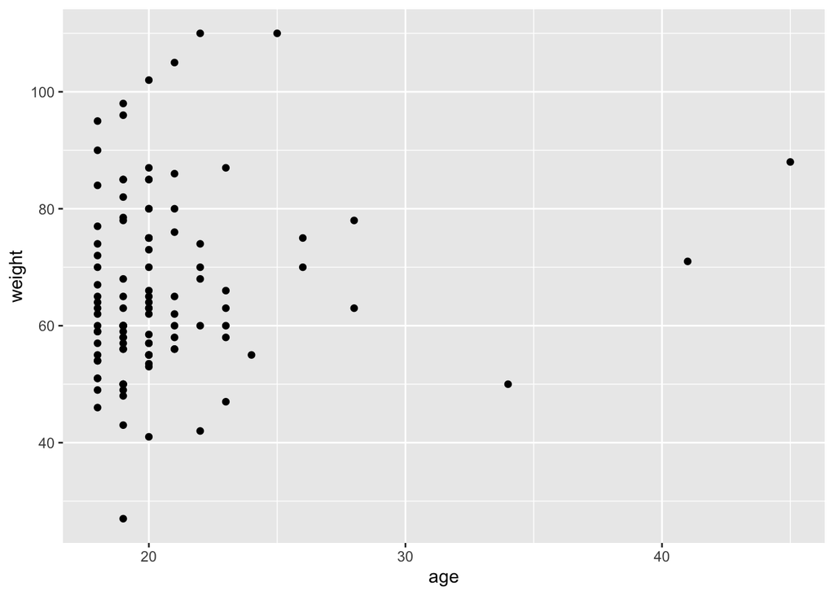

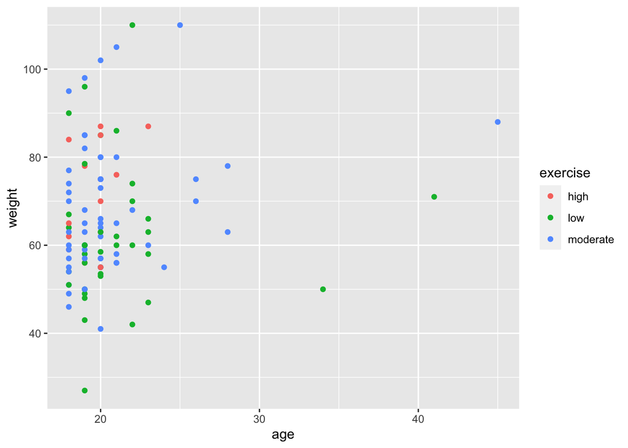

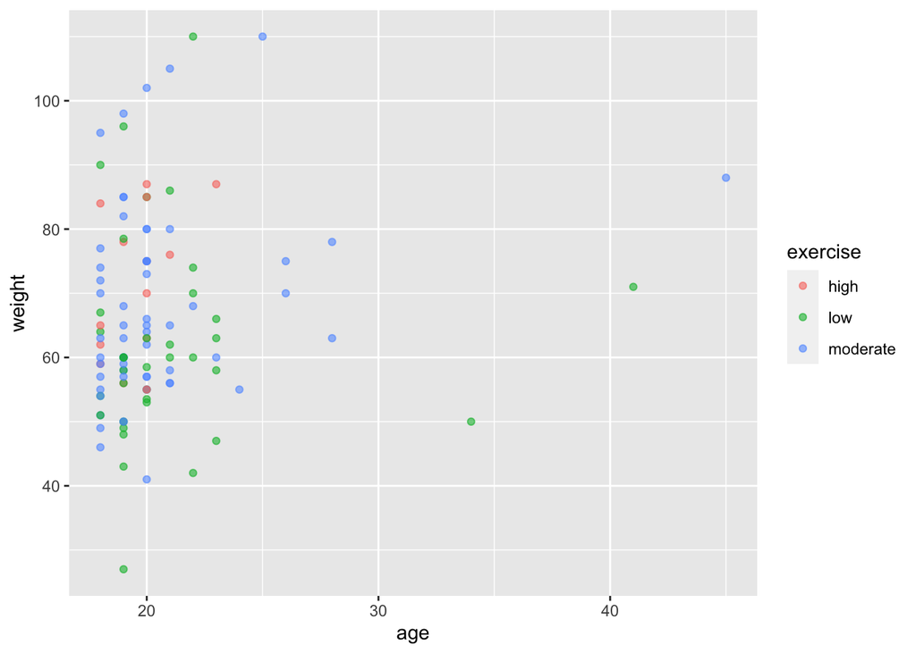

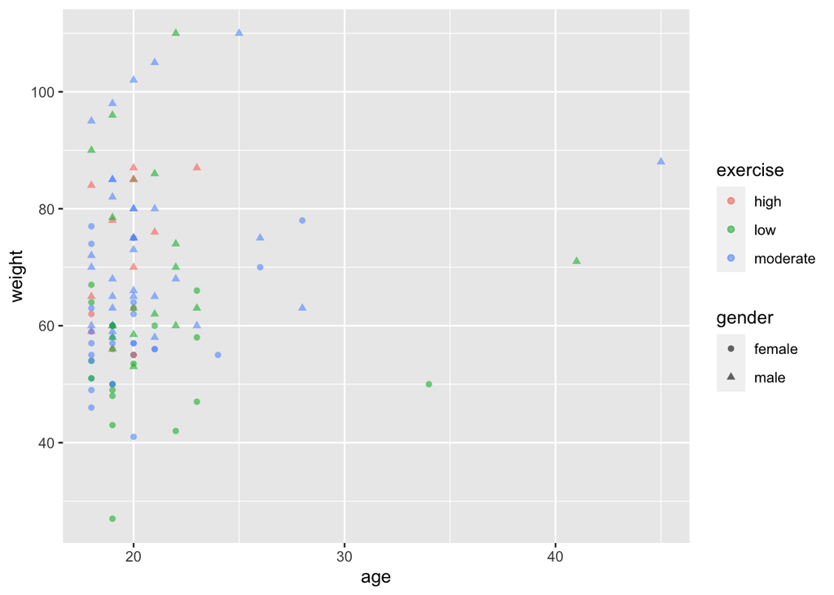

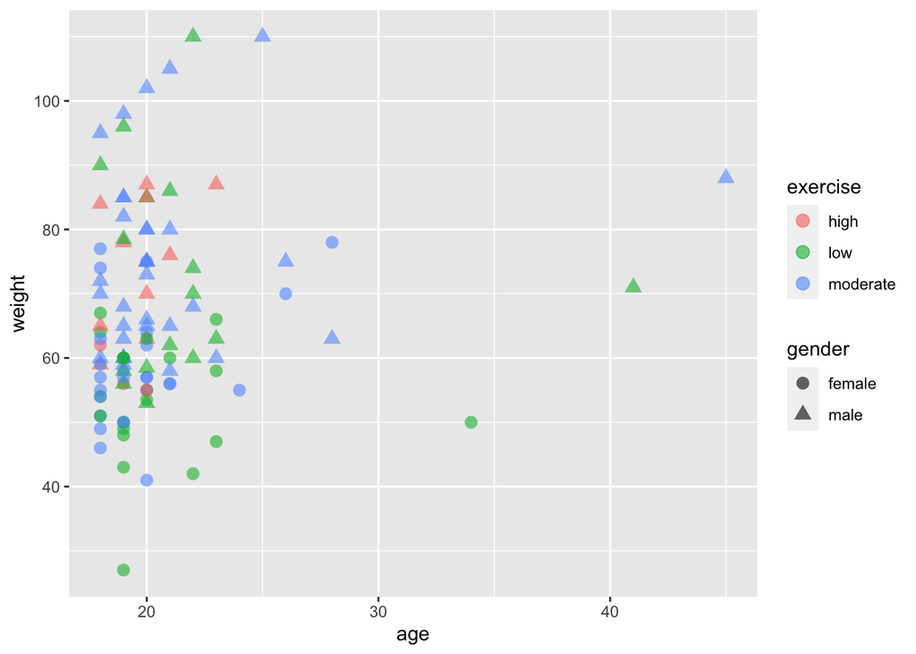

3. *Labels*.  
   Check `Help` for commands `xlab`, `ylab`, `ggtitle`.  
   Adjust the last chart to get the chart below.

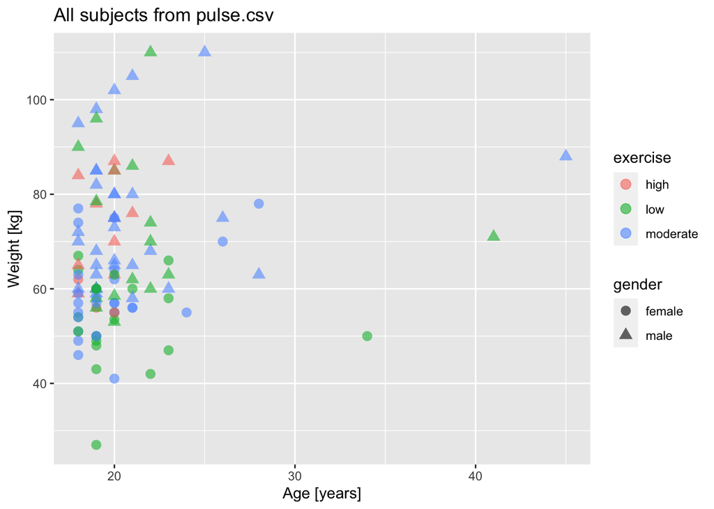

## Extra exercises

1. *Multiple layers*.  
   There can be more than one `geom_` component in a single plot.  
   Compose two `geom_point` components (so, add one more than used above) to reproduce the following chart.

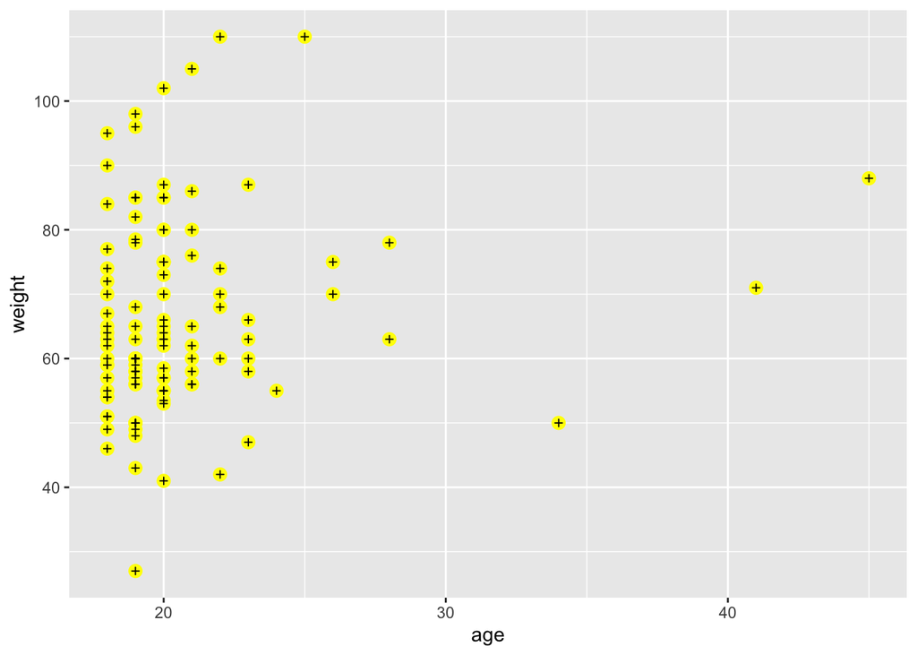

2. *Different data in layers*.  
   By default, `geom_` functions use the data provided in the call to the `ggplot` function.  
   This can be changed with the `data` argument: `geom_point( data = otherData )`.  
   Use the function `filter` to select from `pulse` all subjects with `height >= 190`; store the result in `filtPulse`. Now, modify the previous plot to draw the black symbol only for `filtPulse` subjects.

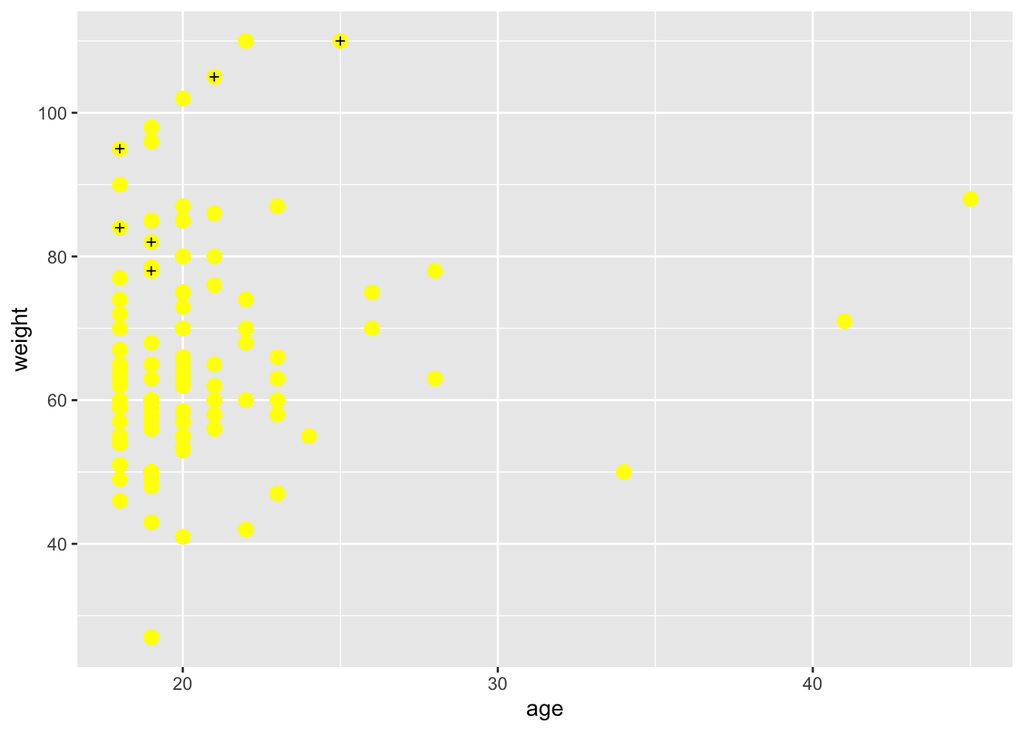